# Bayesian GLMM Part4

```r
mckeon_brm4$fit |>
  tidyMCMC(
    estimate.method = "median",
    conf.int = TRUE, conf.method = "HPDinterval",
    rhat = TRUE, ess = TRUE
  )
```

```
# A tibble: 60 × 7
   term                        estimate std.error conf.low conf.high  rhat   ess
   <chr>                          <dbl>     <dbl>    <dbl>     <dbl> <dbl> <int>
 1 b_Intercept                    2.95      1.10   8.82e-1     5.15  1.000  2173
 2 b_SYMBIONTcrabs               -1.44      1.71  -4.24e+0     2.46  1.000  2083
 3 b_SYMBIONTshrimp              -2.19      1.49  -5.33e+0     0.655 1.00   1822
 4 b_SYMBIONTboth                -3.32      1.45  -6.26e+0    -0.419 1.000  1815
 5 sd_BLOCK__Intercept            2.15      1.19   2.44e-3     4.21  1.000  1634
 6 sd_BLOCK__SYMBIONTcrabs        3.40      3.47   2.23e-3     9.10  0.999  1871
 7 sd_BLOCK__SYMBIONTshrimp       2.39      2.24   2.82e-3     6.68  1.00   1959
 8 sd_BLOCK__SYMBIONTboth         2.41      2.33   1.73e-4     6.62  0.999  2097
 9 cor_BLOCK__Intercept__SYMB…    0.306     0.396 -4.52e-1     0.945 0.999  2149
10 cor_BLOCK__Intercept__SYMB…    0.271     0.409 -5.11e-1     0.934 1.000  2162
# ℹ 50 more rows
```

**Conclusions:**

see above

**gather_draws**

Due to the presence of a log transform in the predictor, it is better to use the regex version.

```r
mckeon_brm4 |> get_variables()
```

```
 [1] "b_Intercept"
 [2] "b_SYMBIONTcrabs"
 [3] "b_SYMBIONTshrimp"
 [4] "b_SYMBIONTboth"
 [5] "sd_BLOCK__Intercept"
 [6] "sd_BLOCK__SYMBIONTcrabs"
 [7] "sd_BLOCK__SYMBIONTshrimp"
 [8] "sd_BLOCK__SYMBIONTboth"
 [9] "cor_BLOCK__Intercept__SYMBIONTcrabs"
[10] "cor_BLOCK__Intercept__SYMBIONTshrimp"
[11] "cor_BLOCK__SYMBIONTcrabs__SYMBIONTshrimp"
[12] "cor_BLOCK__Intercept__SYMBIONTboth"
[13] "cor_BLOCK__SYMBIONTcrabs__SYMBIONTboth"
[14] "cor_BLOCK__SYMBIONTshrimp__SYMBIONTboth"
[15] "Intercept"
```

[output cut: 52 more lines]

```r
mckeon_draw <- mckeon_brm4 |>
  gather_draws(`b.Intercept.*|b_SYMBIONT.*`, regex = TRUE)
mckeon_draw
```

```
# A tibble: 9,600 × 5
# Groups:   .variable [4]
   .chain .iteration .draw .variable   .value
    <int>      <int> <int> <chr>        <dbl>
 1      1          1     1 b_Intercept   2.61
 2      1          2     2 b_Intercept   2.98
 3      1          3     3 b_Intercept   2.14
 4      1          4     4 b_Intercept   2.68
 5      1          5     5 b_Intercept   2.09
 6      1          6     6 b_Intercept   3.29
 7      1          7     7 b_Intercept   2.41
 8      1          8     8 b_Intercept   2.50
 9      1          9     9 b_Intercept   1.78
10      1         10    10 b_Intercept   2.60
# ℹ 9,590 more rows
```

We can then summarise this

```r
mckeon_draw |> median_hdci()
```

```
# A tibble: 4 × 7
  .variable        .value .lower .upper .width .point .interval
  <chr>             <dbl>  <dbl>  <dbl>  <dbl> <chr>  <chr>
1 b_Intercept        2.83  0.882  5.15    0.95 median hdci
2 b_SYMBIONTboth    -3.30 -6.19  -0.335   0.95 median hdci
3 b_SYMBIONTcrabs   -1.61 -4.24   2.46    0.95 median hdci
4 b_SYMBIONTshrimp  -2.29 -5.15   0.857   0.95 median hdci
```

```r
## On a odd ratio scale
mckeon_draw |>
  mutate(.value = exp(.value)) |>
  median_hdci()
```

```
# A tibble: 4 × 7
  .variable         .value   .lower  .upper .width .point .interval
  <chr>              <dbl>    <dbl>   <dbl>  <dbl> <chr>  <chr>
1 b_Intercept      17.0    0.949    136.      0.95 median hdci
2 b_SYMBIONTboth    0.0368 0.000110   0.367   0.95 median hdci
3 b_SYMBIONTcrabs   0.201  0.00125    5.74    0.95 median hdci
4 b_SYMBIONTshrimp  0.101  0.000965   1.48    0.95 median hdci
```

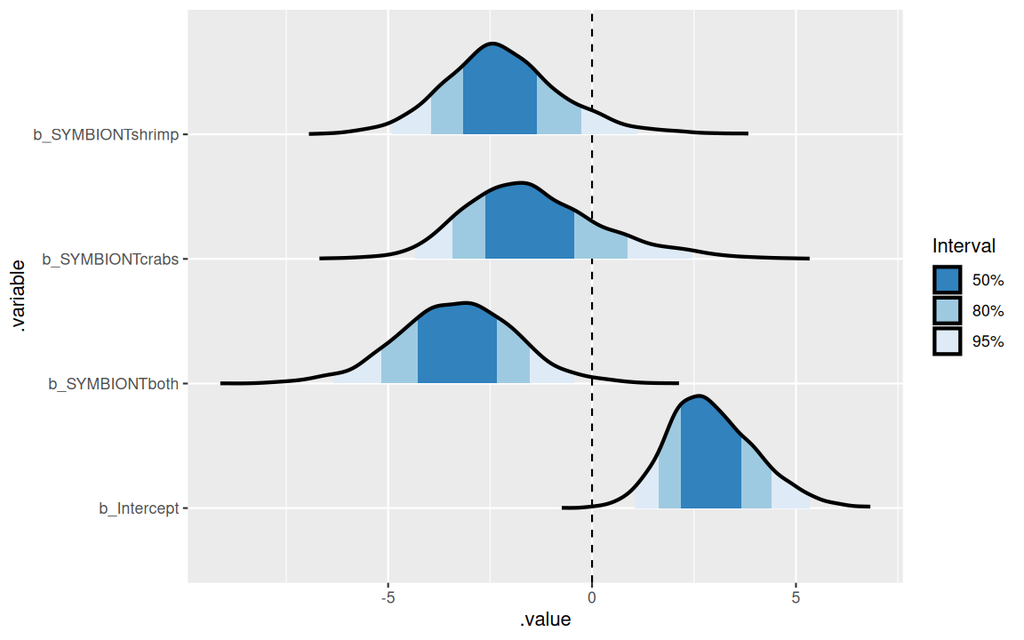

```r
mckeon_brm4 |>
  gather_draws(`b_Intercept.*|b_SYMBIONT.*`, regex = TRUE) |>
  ggplot() +
  geom_vline(xintercept = 0, linetype = "dashed") +
  stat_slab(aes(
    x = .value, y = .variable,
    fill = stat(ggdist::cut_cdf_qi(cdf,
      .width = c(0.5, 0.8, 0.95),
      labels = scales::percent_format()
    ))
  ), color = "black") +
  scale_fill_brewer("Interval", direction = -1, na.translate = FALSE)
```

[figure not shown]

```r
mckeon_brm4 |>
  gather_draws(`.Intercept.*|b_SYMBIONT.*`, regex = TRUE) |>
  ggplot() +
  geom_vline(xintercept = 0, linetype = "dashed") +
  stat_halfeye(aes(x = .value, y = .variable)) +
  theme_classic()
```

**bayesplot**

```
'pars' not specified. Showing first 10 parameters by default.
```

```
ci_level: 0.8 (80% intervals)
```

```
outer_level: 0.95 (95% intervals)
```

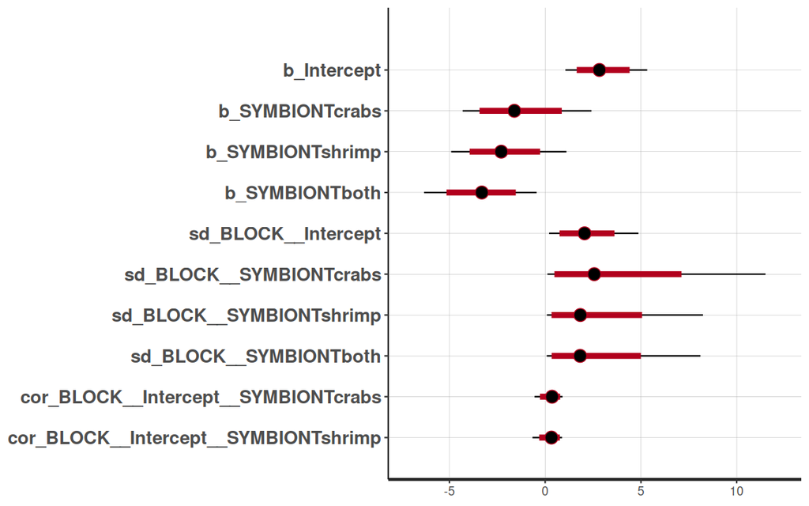

```r
mckeon_brm4$fit |> plot(type = "intervals")
```

**half-eye (ggdist)**

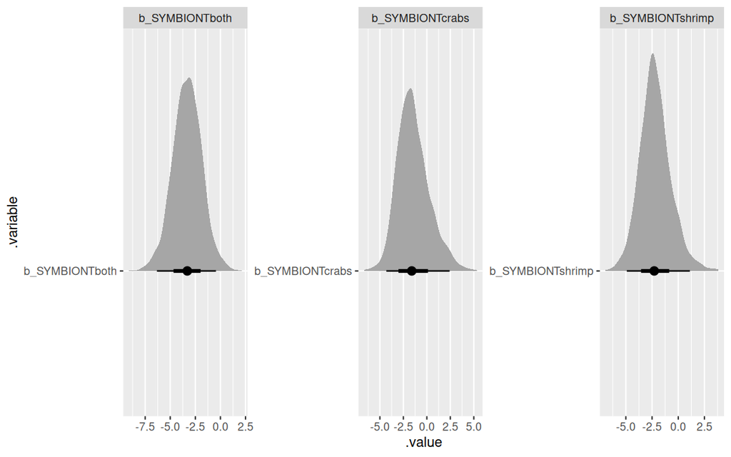

```r
mckeon_brm4 |>
  gather_draws(`^b_.*`, regex = TRUE) |>
  filter(.variable != "b_Intercept") |>
  ggplot() +
  stat_halfeye(aes(x = .value, y = .variable)) +
  facet_wrap(~.variable, scales = "free")
```

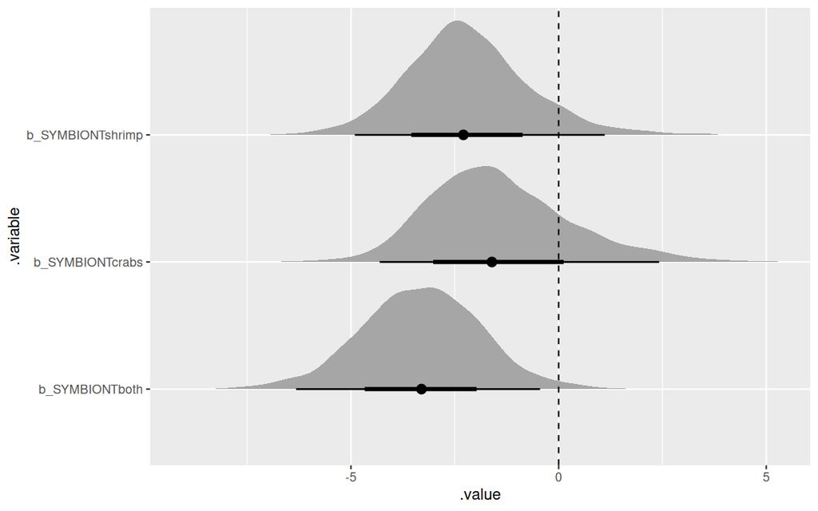

```r
mckeon_brm4 |>
  gather_draws(`^b_.*`, regex = TRUE) |>
  filter(.variable != "b_Intercept") |>
  ggplot() +
  stat_halfeye(aes(x = .value, y = .variable)) +
  geom_vline(xintercept = 0, linetype = "dashed")
```

**density ridges (ggridges)**

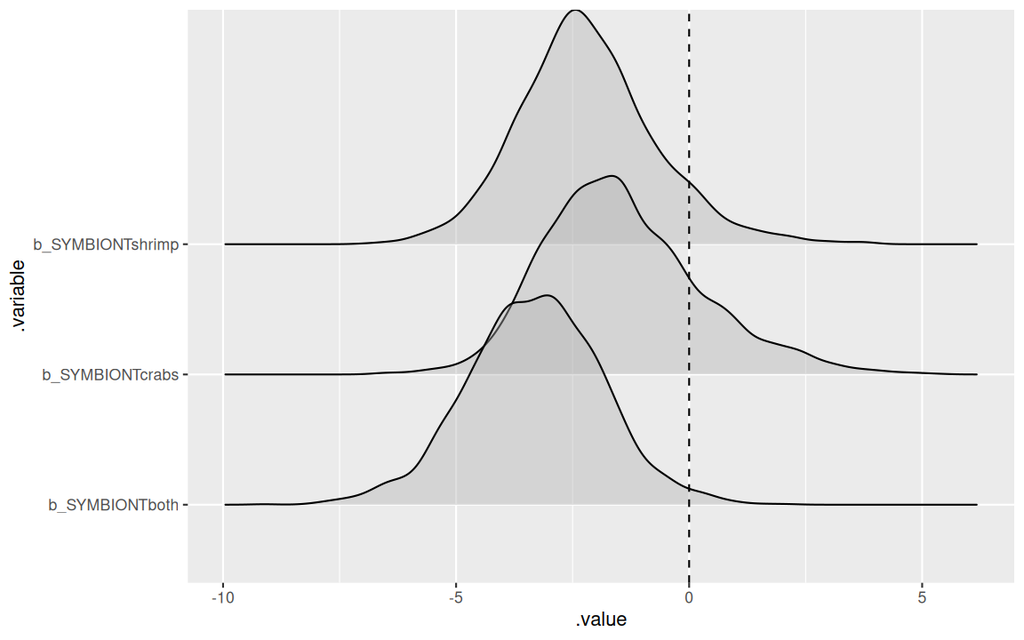

```r
mckeon_brm4 |>
  gather_draws(`^b_.*`, regex = TRUE) |>
  filter(.variable != "b_Intercept") |>
  ggplot() +
  geom_density_ridges(aes(x = .value, y = .variable), alpha = 0.4) +
  geom_vline(xintercept = 0, linetype = "dashed")
```

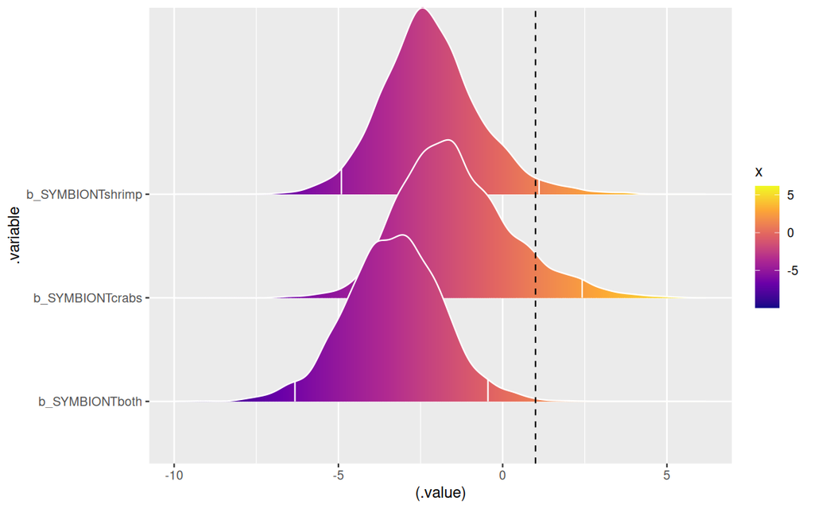

```r
## Or in colour
mckeon_brm4 |>
  gather_draws(`^b_.*`, regex = TRUE) |>
  filter(.variable != "b_Intercept") |>
  ggplot() +
  geom_density_ridges_gradient(
    aes(
      x = (.value),
      y = .variable,
      fill = stat(x)
    ),
    alpha = 0.4, colour = "white",
    quantile_lines = TRUE,
    quantiles = c(0.025, 0.975)
  ) +
  geom_vline(xintercept = 1, linetype = "dashed") +
  scale_x_continuous() +
  scale_fill_viridis_c(option = "C")
```

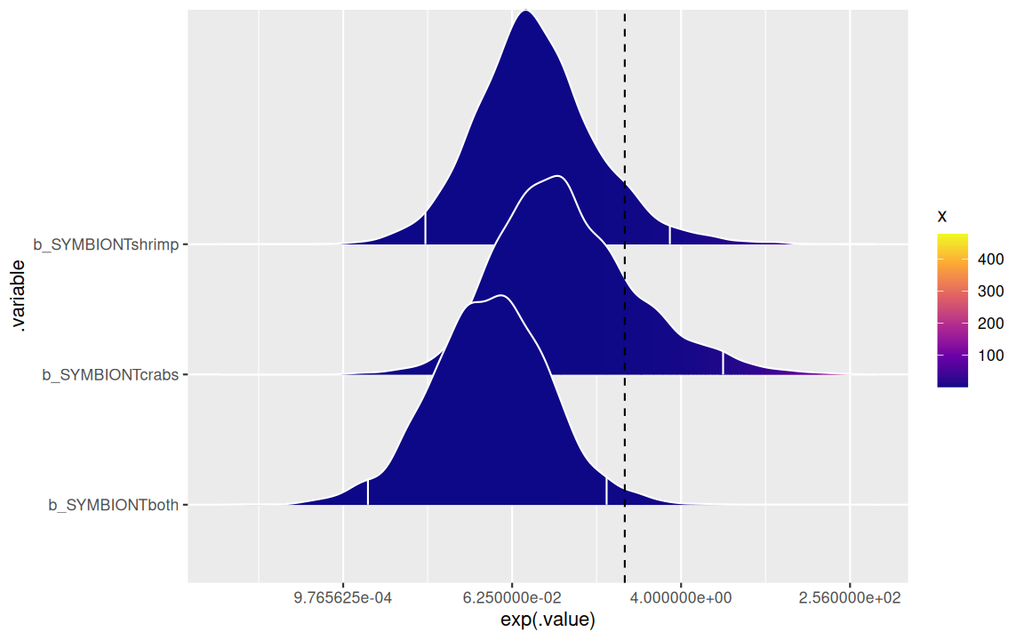

```r
## Fractional scale
mckeon_brm4 |>
  gather_draws(`^b_.*`, regex = TRUE) |>
  filter(.variable != "b_Intercept") |>
  ggplot() +
  geom_density_ridges_gradient(
    aes(
      x = exp(.value),
      y = .variable,
      fill = stat(x)
    ),
    alpha = 0.4, colour = "white",
    quantile_lines = TRUE,
    quantiles = c(0.025, 0.975)
  ) +
  geom_vline(xintercept = 1, linetype = "dashed") +
  scale_x_continuous(trans = scales::log2_trans()) +
  scale_fill_viridis_c(option = "C")
```

**tidy_draws**

```r
mckeon_brm4 |> tidy_draws()
```

```
# A tibble: 2,400 × 70
   .chain .iteration .draw b_Intercept b_SYMBIONTcrabs b_SYMBIONTshrimp
    <int>      <int> <int>       <dbl>           <dbl>            <dbl>
 1      1          1     1        2.61           0.558           -1.52
 2      1          2     2        2.98          -3.58            -2.42
 3      1          3     3        2.14          -0.416           -0.366
 4      1          4     4        2.68          -1.13            -2.36
 5      1          5     5        2.09           1.07            -2.01
 6      1          6     6        3.29          -2.98            -2.56
 7      1          7     7        2.41          -1.62            -0.897
 8      1          8     8        2.50          -1.37            -2.22
 9      1          9     9        1.78          -0.378           -0.835
10      1         10    10        2.60          -2.85            -3.29
# ℹ 2,390 more rows
# ℹ 64 more variables: b_SYMBIONTboth <dbl>, sd_BLOCK__Intercept <dbl>,
#   sd_BLOCK__SYMBIONTcrabs <dbl>, sd_BLOCK__SYMBIONTshrimp <dbl>,
#   sd_BLOCK__SYMBIONTboth <dbl>, cor_BLOCK__Intercept__SYMBIONTcrabs <dbl>,
#   cor_BLOCK__Intercept__SYMBIONTshrimp <dbl>,
#   cor_BLOCK__SYMBIONTcrabs__SYMBIONTshrimp <dbl>,
#   cor_BLOCK__Intercept__SYMBIONTboth <dbl>, …
```

**spread_draws**

```r
mckeon_brm4 |> spread_draws(`.*Intercept.*|b_SYMBIONT.*`, regex = TRUE)
```

```
# A tibble: 2,400 × 23
   .chain .iteration .draw b_Intercept b_SYMBIONTcrabs b_SYMBIONTshrimp
    <int>      <int> <int>       <dbl>           <dbl>            <dbl>
 1      1          1     1        2.61           0.558           -1.52
 2      1          2     2        2.98          -3.58            -2.42
 3      1          3     3        2.14          -0.416           -0.366
 4      1          4     4        2.68          -1.13            -2.36
 5      1          5     5        2.09           1.07            -2.01
 6      1          6     6        3.29          -2.98            -2.56
 7      1          7     7        2.41          -1.62            -0.897
 8      1          8     8        2.50          -1.37            -2.22
 9      1          9     9        1.78          -0.378           -0.835
10      1         10    10        2.60          -2.85            -3.29
# ℹ 2,390 more rows
# ℹ 17 more variables: b_SYMBIONTboth <dbl>, sd_BLOCK__Intercept <dbl>,
#   cor_BLOCK__Intercept__SYMBIONTcrabs <dbl>,
#   cor_BLOCK__Intercept__SYMBIONTshrimp <dbl>,
#   cor_BLOCK__Intercept__SYMBIONTboth <dbl>, Intercept <dbl>,
#   `r_BLOCK[1,Intercept]` <dbl>, `r_BLOCK[2,Intercept]` <dbl>,
#   `r_BLOCK[3,Intercept]` <dbl>, `r_BLOCK[4,Intercept]` <dbl>, …
```

**posterior_samples**

```r
mckeon_brm4 |>
  posterior_samples() |>
  as_tibble()
```

```
# A tibble: 2,400 × 61
   b_Intercept b_SYMBIONTcrabs b_SYMBIONTshrimp b_SYMBIONTboth
         <dbl>           <dbl>            <dbl>          <dbl>
 1        2.61           0.558           -1.52           -4.24
 2        2.98          -3.58            -2.42           -2.78
 3        2.14          -0.416           -0.366          -2.76
 4        2.68          -1.13            -2.36           -1.66
 5        2.09           1.07            -2.01           -1.70
 6        3.29          -2.98            -2.56           -4.25
 7        2.41          -1.62            -0.897          -1.92
 8        2.50          -1.37            -2.22           -5.08
 9        1.78          -0.378           -0.835          -2.31
10        2.60          -2.85            -3.29           -1.95
# ℹ 2,390 more rows
# ℹ 57 more variables: sd_BLOCK__Intercept <dbl>,
#   sd_BLOCK__SYMBIONTcrabs <dbl>, sd_BLOCK__SYMBIONTshrimp <dbl>,
#   sd_BLOCK__SYMBIONTboth <dbl>, cor_BLOCK__Intercept__SYMBIONTcrabs <dbl>,
#   cor_BLOCK__Intercept__SYMBIONTshrimp <dbl>,
#   cor_BLOCK__SYMBIONTcrabs__SYMBIONTshrimp <dbl>,
#   cor_BLOCK__Intercept__SYMBIONTboth <dbl>, …
```

**\(R^2\)**

```r
mckeon_brm4 |>
  bayes_R2(re.form = NA, summary = FALSE) |>
  median_hdci()
```

```
          y        ymin     ymax .width .point .interval
1 0.1798171 0.008074149 0.321401   0.95 median      hdci
```

```r
mckeon_brm4 |>
  bayes_R2(re.form = ~ (1 | BLOCK), summary = FALSE) |>
  median_hdci()
```

```
          y      ymin     ymax .width .point .interval
1 0.4706625 0.1406366 0.734526   0.95 median      hdci
```

```r
## if we had random intercept/slope
mckeon_brm4 |>
  bayes_R2(re.form = ~ (SYMBIONT | BLOCK), summary = FALSE) |>
  median_hdci()
```

```
          y      ymin      ymax .width .point .interval
1 0.7080777 0.5762833 0.8229876   0.95 median      hdci
```

**Modelsummary**

```r
mckeon_brm4 |> modelsummary(
  statistic = c("conf.low", "conf.high"),
  shape = term ~ statistic,
  exponentiate = FALSE
)
```

|  | (1) Est. | (1) 2.5 % | (1) 97.5 % |
| --- | --- | --- | --- |
| b_Intercept | 2.832 | 1.056 | 5.327 |
| b_SYMBIONTcrabs | -1.607 | -4.309 | 2.421 |
| b_SYMBIONTshrimp | -2.293 | -4.908 | 1.110 |
| b_SYMBIONTboth | -3.302 | -6.322 | -0.447 |
| sd_BLOCK__Intercept | 2.056 | 0.204 | 4.865 |
| sd_BLOCK__SYMBIONTcrabs | 2.561 | 0.119 | 11.582 |
| sd_BLOCK__SYMBIONTshrimp | 1.837 | 0.088 | 8.240 |
| sd_BLOCK__SYMBIONTboth | 1.827 | 0.081 | 8.105 |
| cor_BLOCK__Intercept__SYMBIONTcrabs | 0.359 | -0.554 | 0.907 |
| cor_BLOCK__Intercept__SYMBIONTshrimp | 0.328 | -0.662 | 0.882 |
| cor_BLOCK__SYMBIONTcrabs__SYMBIONTshrimp | 0.473 | -0.602 | 0.928 |
| cor_BLOCK__Intercept__SYMBIONTboth | 0.246 | -0.682 | 0.877 |
| cor_BLOCK__SYMBIONTcrabs__SYMBIONTboth | 0.357 | -0.677 | 0.900 |
| cor_BLOCK__SYMBIONTshrimp__SYMBIONTboth | 0.425 | -0.604 | 0.921 |
| Num.Obs. | 80 |  |  |
| R2 | 0.708 |  |  |
| R2 Marg. | 0.180 |  |  |
| ICC | 0.9 |  |  |
| ELPD | -25.9 |  |  |
| ELPD s.e. | 6.1 |  |  |
| LOOIC | 51.7 |  |  |
| LOOIC s.e. | 12.2 |  |  |
| WAIC | 49.6 |  |  |
| RMSE | 0.21 |  |  |

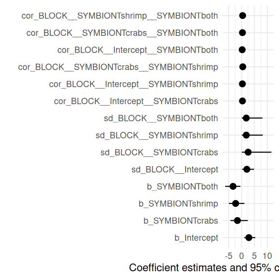

```r
mckeon_brm4 |> modelplot(exponentiate = FALSE)
```

# 10 Further analyses

In addition to comparing each of the symbiont types against the control group of no symbionts, it might be interesting to investigate whether there are any differences between the predation protection provided by crabs and shrimp, as well as whether having both crabs and shrimp symbionts is different to only a single symbiont type.

These contrasts can be explored via specific contrasts.

**Table** 1: Contrast coefficients

| SYMBIONT | Crab vs Shrimp | One vs Both | None vs Symbiont |
| --- | --- | --- | --- |
| none | 0 | 0 | 1 |
| crab | 1 | 1/2 | -1/3 |
| shrimp | -1 | 1/2 | -1/3 |
| both | 0 | -1 | -1/3 |

**brms**

**Pairwise comparisons**

```r
mckeon_brm4 |>
  emmeans(~SYMBIONT, type = "response") |>
  pairs()
```

```
 contrast       odds.ratio lower.HPD upper.HPD
 none / crabs         4.99  0.004819      47.6
 none / shrimp        9.91  0.021648      88.6
 none / both         27.17  0.118648     287.4
 crabs / shrimp       2.02  0.000632      47.8
 crabs / both         5.80  0.009004     183.7
 shrimp / both        2.77  0.008164      45.6

Point estimate displayed: median
Results are back-transformed from the log odds ratio scale
HPD interval probability: 0.95
```

```r
# via tidy_draws
mckeon_em <-
  mckeon_brm4 |>
  emmeans(~SYMBIONT, type = "link") |>
  pairs() |>
  tidy_draws() |>
  mutate(across(starts_with("contrast"), exp)) |>
  summarise_draws(median,
    HDInterval::hdi,
    Pl = ~ mean(.x < 1),
    Pg = ~ mean(.x > 1),
    ROPE = ~ mean(.x < 1.1 & .x > 0.9)
  )
mckeon_em
```

```
# A tibble: 6 × 7
  variable                median    lower upper     Pl    Pg    ROPE
  <chr>                    <dbl>    <dbl> <dbl>  <dbl> <dbl>   <dbl>
1 contrast none - crabs     4.99 0.00482   47.6 0.185  0.815 0.0233
2 contrast none - shrimp    9.91 0.0216    88.6 0.0767 0.923 0.0171
3 contrast none - both     27.2  0.119    287.  0.0142 0.986 0.00333
4 contrast crabs - shrimp   2.02 0.000632  47.8 0.340  0.660 0.0429
5 contrast crabs - both     5.80 0.00900  184.  0.136  0.864 0.0288
6 contrast shrimp - both    2.77 0.00816   45.6 0.222  0.778 0.0408
```

```r
# or via gather_emmeans_draws()
mckeon_em <-
  mckeon_brm4 |>
  emmeans(~SYMBIONT, type = "link") |>
  pairs() |>
  gather_emmeans_draws() |>
  mutate(.value = exp(.value)) |>
  summarise(median_hdci(.value),
    Pl = mean(.value < 1),
    Pg = mean(.value > 1)
  )
mckeon_em
```

```
# A tibble: 6 × 9
  contrast           y     ymin  ymax .width .point .interval     Pl    Pg
  <chr>          <dbl>    <dbl> <dbl>  <dbl> <chr>  <chr>      <dbl> <dbl>
1 crabs - both    5.80 0.00900  183.    0.95 median hdci      0.136  0.864
2 crabs - shrimp  2.02 0.000632  47.4   0.95 median hdci      0.340  0.660
3 none - both    27.2  0.119    287.    0.95 median hdci      0.0142 0.986
4 none - crabs    4.99 0.00482   47.6   0.95 median hdci      0.185  0.815
5 none - shrimp   9.91 0.0216    88.5   0.95 median hdci      0.0767 0.923
6 shrimp - both   2.77 0.00816   45.6   0.95 median hdci      0.222  0.778
```

```r
## On a probability scale
mckeon_em <-
  mckeon_brm4 |>
  emmeans(~SYMBIONT, type = "link") |>
  regrid() |>
  pairs() |>
  tidy_draws() |>
  summarise_draws(median,
    HDInterval::hdi,
    Pl = ~ mean(.x < 0),
    Pg = ~ mean(.x > 0)
  )
mckeon_em
```

```
# A tibble: 6 × 6
  variable                median   lower upper     Pl    Pg
  <chr>                    <dbl>   <dbl> <dbl>  <dbl> <dbl>
1 contrast none - crabs   0.139  -0.186  0.643 0.185  0.815
2 contrast none - shrimp  0.265  -0.0636 0.769 0.0767 0.923
3 contrast none - both    0.508   0.0567 0.898 0.0142 0.986
4 contrast crabs - shrimp 0.0958 -0.409  0.652 0.340  0.660
5 contrast crabs - both   0.309  -0.237  0.836 0.136  0.864
6 contrast shrimp - both  0.190  -0.289  0.762 0.222  0.778
```

```r
# or via gather_emmeans_draws()
## mckeon_em <- mckeon_brm4 |>
##     emmeans(~SYMBIONT, type='link') |>
##     pairs() |>
##     gather_emmeans_draws() |>
##     mutate(Eff=exp(.value),
##            PEff=100*(Eff-1))#,
##              # Prob = plogis(.value))
## mckeon_em |> head()
## mckeon_em |>
##     group_by(contrast) |>
##     dplyr::select(contrast, Eff) |>
##     median_hdi()
## mckeon_em |>
##   group_by(contrast) |>
##   summarize(Prob=sum(Eff>1)/n())

## On a probability scale
mckeon_em <- mckeon_brm4 |>
  emmeans(~SYMBIONT, type = "link") |>
  regrid() |>
  pairs() |>
  gather_emmeans_draws() |>
  mutate(Eff = .value) # ,
mckeon_em |> head()
```

```
# A tibble: 6 × 6
# Groups:   contrast [1]
  contrast     .chain .iteration .draw  .value     Eff
  <chr>         <int>      <int> <int>   <dbl>   <dbl>
1 none - crabs     NA         NA     1 -0.0281 -0.0281
2 none - crabs     NA         NA     2  0.597   0.597
3 none - crabs     NA         NA     3  0.0459  0.0459
4 none - crabs     NA         NA     4  0.111   0.111
5 none - crabs     NA         NA     5 -0.0693 -0.0693
6 none - crabs     NA         NA     6  0.387   0.387
```

```r
mckeon_em |>
  group_by(contrast) |>
  dplyr::select(contrast, Eff) |>
  median_hdi()
```

```
# A tibble: 6 × 7
  contrast          Eff  .lower .upper .width .point .interval
  <chr>           <dbl>   <dbl>  <dbl>  <dbl> <chr>  <chr>
1 crabs - both   0.309  -0.215   0.859   0.95 median hdi
2 crabs - shrimp 0.0958 -0.409   0.652   0.95 median hdi
3 none - both    0.508   0.0492  0.891   0.95 median hdi
4 none - crabs   0.139  -0.142   0.689   0.95 median hdi
5 none - shrimp  0.265  -0.0636  0.769   0.95 median hdi
6 shrimp - both  0.190  -0.320   0.732   0.95 median hdi
```

```r
## Cell means
mckeon_em <- emmeans(mckeon_brm4, ~SYMBIONT, type = "link") |>
  gather_emmeans_draws()
mckeon_em |>
  mutate(P = plogis(.value)) |>
  median_hdci(P)
```

```
# A tibble: 4 × 7
  SYMBIONT     P .lower .upper .width .point .interval
  <fct>    <dbl>  <dbl>  <dbl>  <dbl> <chr>  <chr>
1 none     0.944 0.788   0.999   0.95 median hdci
2 crabs    0.794 0.275   1.000   0.95 median hdci
3 shrimp   0.663 0.189   0.999   0.95 median hdci
4 both     0.421 0.0241  0.881   0.95 median hdci
```

**Specific contrasts**

```r
cmat <- cbind(
  "Crab vs shrimp" = c(0, 1, -1, 0),
  "Both vs One" = c(0, -1 / 2, -1 / 2, 1),
  "Any vs None" = c(-1, 1 / 3, 1 / 3, 1 / 3)
)

mckeon_em <- mckeon_brm4 |>
  emmeans(~SYMBIONT, type = "response") |>
  contrast(method = list(cmat))
mckeon_em <-
  mckeon_brm4 |>
  emmeans(~SYMBIONT, type = "link") |>
  contrast(method = list(cmat)) |>
  tidy_draws() |>
  mutate(across(starts_with("contrast"), exp)) |>
  summarise_draws(median,
    HDInterval::hdi,
    Pl = ~ mean(.x < 1),
    Pg = ~ mean(.x > 1)
  )
mckeon_em
```

```
# A tibble: 3 × 6
  variable                median    lower  upper    Pl     Pg
  <chr>                    <dbl>    <dbl>  <dbl> <dbl>  <dbl>
1 contrast Crab vs shrimp 2.02   0.000632 47.8   0.340 0.660
2 contrast Both vs One    0.237  0.000305  2.15  0.861 0.139
3 contrast Any vs None    0.0942 0.00194   0.753 0.969 0.0308
```

```r
## or via gather_emmeans_draws
mckeon_em <-
  mckeon_brm4 |>
  emmeans(~SYMBIONT, type = "link") |>
  contrast(method = list(cmat)) |>
  gather_emmeans_draws() |>
  mutate(Fit = exp(.value)) |>
  summarise(median_hdci(Fit),
    Pl =  mean(Fit < 0),
    Pg =  mean(Fit > 0)
  )
mckeon_em
```

```
# A tibble: 3 × 9
  contrast            y     ymin   ymax .width .point .interval    Pl    Pg
  <chr>           <dbl>    <dbl>  <dbl>  <dbl> <chr>  <chr>     <dbl> <dbl>
1 Any vs None    0.0942 0.00194   0.752   0.95 median hdci          0     1
2 Both vs One    0.237  0.000305  2.15    0.95 median hdci          0     1
3 Crab vs shrimp 2.02   0.000632 47.4     0.95 median hdci          0     1
```

```r
newdata <- emmeans(mckeon_brm4, ~SYMBIONT, type = "response") |> as.data.frame()
head(newdata)
```

```
 SYMBIONT  response lower.HPD upper.HPD
 none     0.9443812 0.7882106 0.9989135
 crabs    0.7944272 0.2751096 0.9997865
 shrimp   0.6632351 0.1895295 0.9995813
 both     0.4212663 0.0091733 0.8548816

Point estimate displayed: median
Results are back-transformed from the logit scale
HPD interval probability: 0.95
```

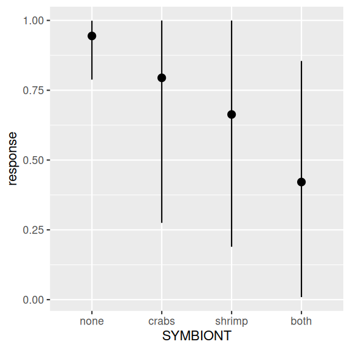

```r
ggplot(newdata, aes(y = response, x = SYMBIONT)) +
  geom_pointrange(aes(ymin = lower.HPD, ymax = upper.HPD))
```

**R^2**

```r
mckeon_brm4 |> bayes_R2(re.form = NA)
```

```
    Estimate  Est.Error       Q2.5     Q97.5
R2 0.1763405 0.09054808 0.01394755 0.3286097
```

```r
mckeon_brm4 |>
  bayes_R2(re.form = NA, summary = FALSE) |>
  median_hdci()
```

```
          y        ymin     ymax .width .point .interval
1 0.1798171 0.008074149 0.321401   0.95 median      hdci
```

```r
mckeon_brm4 |>
  bayes_R2(re.form = ~ (1 | BLOCK), summary = FALSE) |>
  median_hdci()
```

```
          y      ymin     ymax .width .point .interval
1 0.4706625 0.1406366 0.734526   0.95 median      hdci
```

```r
## for random intercept/slope model
mckeon_brm4 |>
  bayes_R2(re.form = ~ (SYMBIONT | BLOCK), summary = FALSE) |>
  median_hdci()
```

```
          y      ymin      ymax .width .point .interval
1 0.7080777 0.5762833 0.8229876   0.95 median      hdci
```

## 11 References

Mckeon, Seabird, Adrian Stier, Shelby Mcilroy, and Benjamin Bolker. 2012. “Multiple Defender Effects: Synergistic Coral Defense by Mutualist Crustaceans.” *Oecologia* 169 (February): 1095–1103. https://doi.org/10.1007/s00442-012-2275-2.